# Modelo de regresión para la predicción de precios de automóviles

Data science essential training

DiplomadosOnline.com

Mayo, 2022

Ejecute las siguientes lineas para continuar.

```r
df = read.csv("data.csv", sep=",", header = TRUE)

library(janitor)
df = clean_names(df)

df$model <- gsub(" ", "_", df$model)
df$engine_fuel_type <- gsub(" ", "_", df$engine_fuel_type)
df$driven_wheels <- gsub(" ", "_", df$driven_wheels)

set.seed(1234)
trvaltest <- function(dat,prop = c(0.6,0.2,0.2)){
  nrw = nrow(dat)
  trnr = as.integer(nrw *prop[1])
  vlnr = as.integer(nrw*prop[2])
  set.seed(123)
  trni = sample(1:nrow(dat),trnr)
  trndata = dat[trni,]
  rmng = dat[-trni,]
  vlni = sample(1:nrow(rmng),vlnr)
  valdata = rmng[vlni,]
  tstdata = rmng[-vlni,]
  mylist = list("trn" = trndata,"val"= valdata,"tst" = tstdata)
  return(mylist)
}
outdata = trvaltest(df,prop = c(0.6,0.2,0.2))
df_train = outdata$trn; df_val = outdata$val; df_test = outdata$tst

library(dplyr)
y_train_orig =  select(df_train, msrp)
y_val_orig = select(df_val, msrp)
y_test_orig = select(df_test, msrp)

y_train = log1p(y_train_orig)
y_val = log1p(y_val_orig)
y_test = log1p(y_test_orig)

df_train <- df_train[ ,!colnames(df_train)=="msrp"]
df_val <- df_val[ ,!colnames(df_val)=="msrp"]
df_test <- df_test[ ,!colnames(df_test)=="msrp"]
```

# 2 ) Modelado de los datos

Tras realizar el análisis inicial de los datos, estamos preparados para entrenar un modelo. El problema que estamos resolviendo es un problema de regresión: el objetivo es predecir un número, el precio de un automovil.

Para este proyecto utilizaremos el modelo de regresión más sencillo: la regresión lineal.

## 2.1 Regresión lineal

En primer lugar, repasemos cómo funciona la regresión lineal

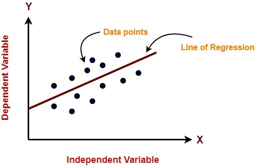

Regresión lineal

Supongamos que tenemos una observación simple $x_{i}$ y el valor y $i$ que queremos predecir. El ı́ndice $i$ significa aquı́ que se trata de la observación número $i$, una de las $m$ observaciones que tenemos en nuestro conjunto de datos de entrenamiento.

Si tenemos $n$ caracterı́sticas, nuestro vector $x_{i}$ serı́a $n−$dimensional, por lo que tiene $n$ componentes:

[x_{i} = (x_{i1},x_{i2},…, x_{in})]

En nuestro caso, tenemos $7,150$ autos en el conjunto de datos de entrenamiento. Esto significa que $m = 7,150$ y $i$ puede ser cualquier número entre 0 y 7,149.

donde, $\beta_{0},..., \beta_{n}$ son los parámetros del modelo:

- $\beta_{0}$ es el término de sesgo
- $\beta_{1},...,\beta_{n}$ son las ponderaciones de cada caracterı́stica $x_{i1},x_{i2},..., x_{in}$.

Estos parámetros definen exactamente cómo debe combinar el modelo las caracterı́sticas para que las predicciones al final sean lo mejor posible.

**Entrenamiento:**

¿Cuáles son $x_{i}$ e $y_{i}$ para este problema?

Estas ponderaciones son las que aprende el modelo cuando lo entrenamos.

Este modelo lo podemos escribir es forma matricial como:

$f(X) = \beta_{0} + X β ,$

donde, $\beta$ es el vector columna de los coeficientes $\beta_{1} , \beta_{2} , ..., \beta_{n}$ , mientras $X$ es lo que se conoce como la matiz de diseño que contiene todas las observaciones de las caracterı́sticas consideradas.

## 2.2 Entrenamiento del modelo de regresión

Para poder hacer prediciones, necesitamos saber las ponderaciones $\beta$. ¿Cómo las obtenemos?

Aprendemos los pesos a partir de los datos: utilizamos la variable objetivo $y$ para encontrar la beta que combina las caracterı́sticas de $X$ de la mejor manera posible.

En el caso de la regresión lineal, “la mejor manera posible”significa que minimiza el error entre las predicciones $f(X)$ y el objetivo real $y$.

Tenemos varias formas de hacerlo. Utilizaremos la ecuación normal, que es el método más sencillo. El vector de pesos $\beta$ se puede calcular con la siguiente fórmula:

$\beta = (X^{T}X)^{−1} X^{T}y$

Para implementar la ecuación normal, tenemos que hacer lo siguiente:

- Crear una función que tome una matriz $X$ con caracterı́sticas y un vector $y$ con el objetivo.
- Añadir una columna ficticia (la caracterı́stica que siempre se pone en 1) a la matriz $X$.
- Entrena el modelo: calcula los pesos $\beta$ mediante la ecuación normal.
- Dividir este $\beta$ en el sesgo $\beta_{0}$ y el resto de los pesos, y devolverlos.
- El último paso (dividir $\beta$ en el término de sesgo y el resto) es opcional y se hace principalmente por conveniencia.

La implementación serı́a:

```r
train_linear_regression = function(X,y){
    ones = as.vector(rep(1, dim(X)[1]))
    X = cbind(ones, X)

    XTX = t(X) %*% X
    XTX_inv = solve(XTX)
    w = XTX_inv %*% t(X) %*% y

    w
}
```

**Entrenamiento:**

Explique cada linea de la función e identifı́quela con los pasos señalados.